# Model Fitting on Abortion Rates

https://mgimond.github.io/Spatial/spatial-autocorrelation-in-r.html Stat 141 files that Alex emailed to me

## Neighbors and Weights

States serve as the geographic units of this analysis, so I must import the pre-computed neighborhood object from GADM, which contains location information for each of the 50 states. Because this analysis is focusing on the contiguous United States, I drop Hawaii and Alaska from the observations. Then, I merge the location data with my dataframe containing the abortion data.

I create a neighbors list using `poly2nb()` from the `spdep` package, and I build a binary weight matrix from that. Creating the neighbors in this manner will classify two states as neighbors if they share a boundary. If I wish to change this in the future, I can classify two states as neighbors if their centroids lie within a specified distance using `dnearneigh()` instead of `poly2nb()`. Alternatively, I could instead use `knn2nb()` to compute $k$ neighborhood assignments based on the number of nearest neighbors.

For now, this analysis will adopt the `poly2nb()` approach that focuses on shared boundaries. This approach operates under the assumption that states sharing borders are most likely to share spatial characteristics not captured by the predictors included in the model. In the case of abortion spillover, it makes sense that women will cross as few state lines as possible to obtain an abortion. One could also make the case for distance-based neighborhood classifications using `dnearneigh()`, since tight clusters of states in regions such as New England likely share many regional characteristics even if they are not direct neighbors. However, this approach creates the need to select some distance cutoff, and selecting this metric such that it will capture direct neighbors in regions with large states with distant centroids and indirect neighbors in regions with small states relies on some rather arbitrary decisions.

I then convert the list of neighbors into a matrix where entry $W_{ij}$ contains the weight of the connection from state $i$ **to** state $j$. We build our weights matrix with binary weights such that $W_{ij}=1$ if $j$ is a neighbor of $i$ is zero otherwise. Then, I normalized the rows of the matrix such that each row of $B$ will sum to $1$ and $W_{ij} = \frac{B_{ij}}{\sum_{j} B_{ij}}.$

```r
# {
  {
    # getting spatial data for US state boundaries & subsetting out Alaska & Hawaii
    # (using tutorial at https://mhallwor.github.io/_pages/basics_SpatialPolygons)

    usa <- raster::getData('GADM', country='USA', level=1)
    usa <- usa[!usa$NAME_1 %in% c('Alaska', 'Hawaii'),]

    # merging with data

    usa <- merge(usa, nbin_df,
                 by.x = 'NAME_1', by.y = 'state',
                 duplicateGeoms = TRUE, all.x = FALSE)
  }
#
#   # using poly2nb to create a neighbors list & from that a neighbors matrix
#   # https://rspatial.org/raster/rosu/Chapter7.html
#
#   ### ******* I MAY WANT TO ADD A SNAP ARGUMENT IN THE FUTURE TO CONSIDER BOUNDARY
#   ### POINTS LESS THAN SNAP DISTANCE APART AS NEIGHBORS... STATES THAT DO NOT
#   ### SHARE BOUNDARIES ARE STILL CLOSE TO ONE ANOTHER AND HAVE REASONABLE
#   ### SPILLOVER / REGIONAL CORRELATION **********
#   # maybe specify neighbors with dnearneigh instead?
#
#   usa_contig <- poly2nb(usa, queen=FALSE)
#   usa_contig
#
# }

# writing the nb object to a file so that I don't have to recreate it every time
# (it takes forever) & can just read it in directly

#write.nb.gal(usa_contig, 'raw-data/helper/usa_contig_nb.gal')
usa_contig <- read.gal('raw-data/helper/usa_contig_nb.gal')

# check for symmetric relationships (since if TX is a neighbor of OK, OK should
# also be a neighbor of TX)

is.symmetric.nb(usa_contig)
```

```
## [1] TRUE
```

```r
# build binary weight matrix

weights.contig.B <- nb2listw(usa_contig, style = "B")
print(weights.contig.B)
```

```
## Characteristics of weights list object:
## Neighbour list object:
## Number of regions: 339
## Number of nonzero links: 14066
## Percentage nonzero weights: 12.23971
## Average number of links: 41.49263
##
## Weights style: B
## Weights constants summary:
##     n     nn    S0    S1      S2
## B 339 114921 14066 28132 2765720
```

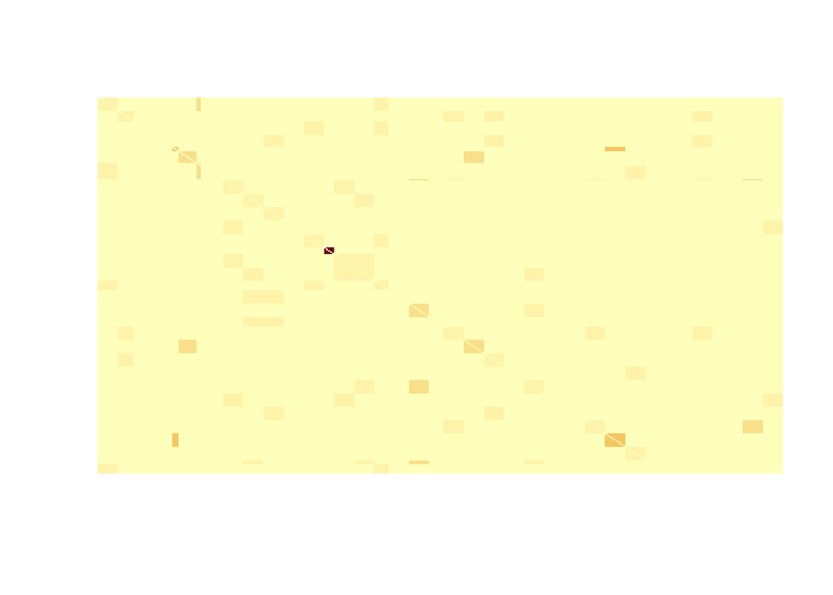

```r
# rescaling each row of B to sum to 1

weights.contig.W <- nb2listw(usa_contig)
image(listw2mat(weights.contig.W)[,281:1],
      axes = FALSE)
```

**it’s not in kilometers, so figure out what it is**

We can also create custom weights using the inverse distance between the centroids of states. In the below code, I define $W_{ij}$ as the inverse of the distance between $i$ and $j$ in $km$ when $i$ and $j$ are neighbors, and 0 otherwise.

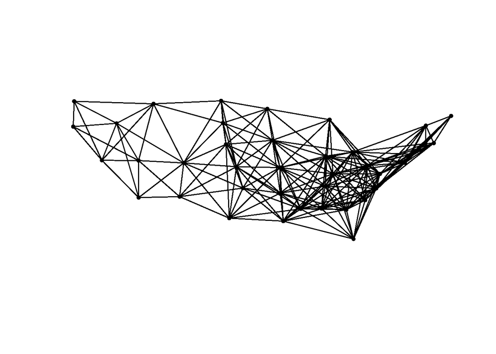

```r
# creating distance-based neighbors

usa.dist.range <- dnearneigh(coordinates(usa),
                            d1 = 0, # specify lower bound of range
                            d2 = 11 # specify upper bound of range
                            )
{
  # plot(usa, border="grey60", axes=FALSE, main = "Neighbors based on Distance Cutoff")
  plot(usa.dist.range, coordinates(usa), pch=19, cex=0.6)
}
```

```r
# creating weights based on the inverse distance

inv.dist <- lapply(nbdists(usa.dist.range, coordinates(usa)),
                   function(x) ifelse(x!=0, 1e3/(x), x))
weights.inv.dist <- nb2listw(usa.dist.range,
                             glist = inv.dist, # specify weights
                             style = "B")
# note style B uses the weights specified by inv.dist,
# setting style = W will renormalize the weights to sum to one

print(weights.inv.dist)
```

```
## Characteristics of weights list object:
## Neighbour list object:
## Number of regions: 339
## Number of nonzero links: 37310
## Percentage nonzero weights: 32.46578
## Average number of links: 110.059
##
## Weights style: B
## Weights constants summary:
##     n     nn      S0         S1           S2
## B 339 114921 5942579 2666995190 507422779195
```

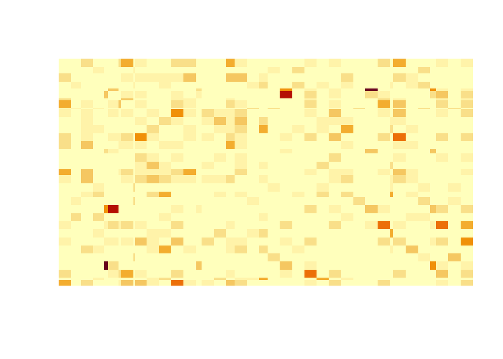

```r
image(listw2mat(weights.inv.dist)[,281:1],
      axes = FALSE)
```

## Testing for Spatial Autocorrelation

When testing for spatial autocorrelation in abortion rates globally, we see that the data demonstrates spatial autocorrelation at the $\alpha=0.05$ significance level.

```r
# moran test on row-normalized weights for contiguous neighbors

moran.test(usa$abortion_per_1k_births,
           listw = weights.contig.W)
```

```
##
##  Moran I test under randomisation
##
## data:  usa$abortion_per_1k_births
## weights: weights.contig.W
##
## Moran I statistic standard deviate = 32.691, p-value < 2.2e-16
## alternative hypothesis: greater
## sample estimates:
## Moran I statistic       Expectation          Variance
##      0.4432915409     -0.0029585799      0.0001863323
```

```r
# moran test using the inverse weighted distance

moran.test(usa$abortion_per_1k_births,
           listw = weights.inv.dist)
```

```
##
##  Moran I test under randomisation
##
## data:  usa$abortion_per_1k_births
## weights: weights.inv.dist
##
## Moran I statistic standard deviate = 27.586, p-value < 2.2e-16
## alternative hypothesis: greater
## sample estimates:
## Moran I statistic       Expectation          Variance
##      1.930737e-01     -2.958580e-03      5.049765e-05
```

## Model fitting

### OLS

#### SHOULD I SQRT THE Y-VALUES? even though it loses its easy interpretability & the difference in the distributions is pretty negligible

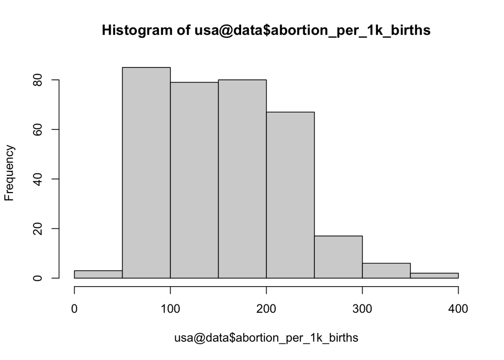

```r
hist(usa@data$abortion_per_1k_births)
```

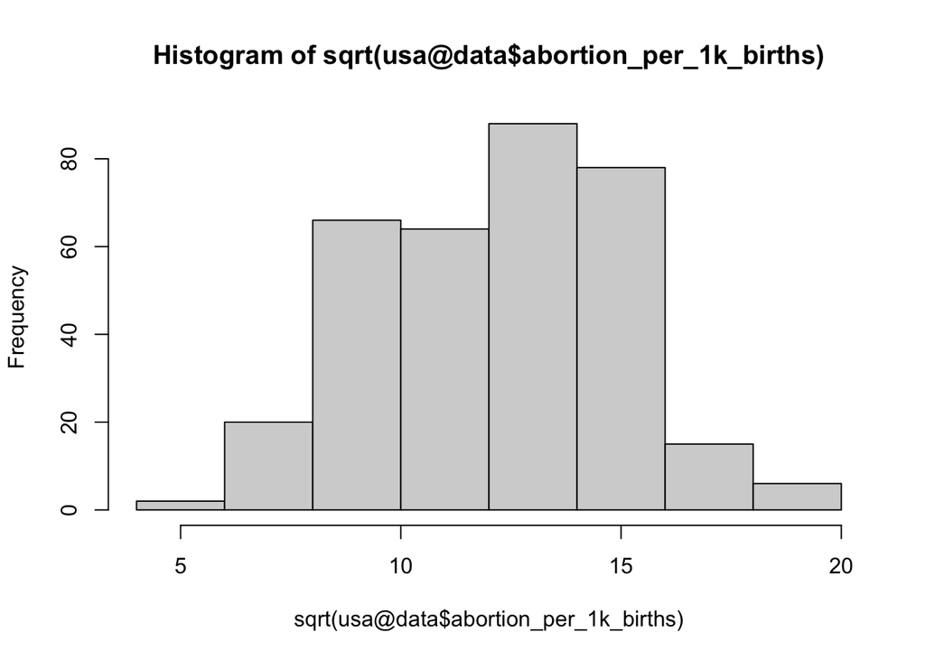

```r
hist(sqrt(usa@data$abortion_per_1k_births))
```

#### INTERPRET MORAN TEST

Ignoring spatial dependence for the moment, we can fit a standard linear model

```r
rate_lm <- lm(abortion_per_1k_births ~ within_between + pct_bachelors +
                            prop_hisp + prop_nonwhite + hh_income + dem_2party,
            data = usa@data)
lm.morantest(rate_lm, listw = weights.contig.W)
```

```
##
##  Global Moran I for regression residuals
##
## data:
## model: lm(formula = abortion_per_1k_births ~ within_between +
## pct_bachelors + prop_hisp + prop_nonwhite + hh_income + dem_2party,
## data = usa@data)
## weights: weights.contig.W
##
## Moran I statistic standard deviate = 11.958, p-value < 2.2e-16
## alternative hypothesis: greater
## sample estimates:
## Observed Moran I      Expectation         Variance
##     0.1070250006    -0.0154750402     0.0001049408
```

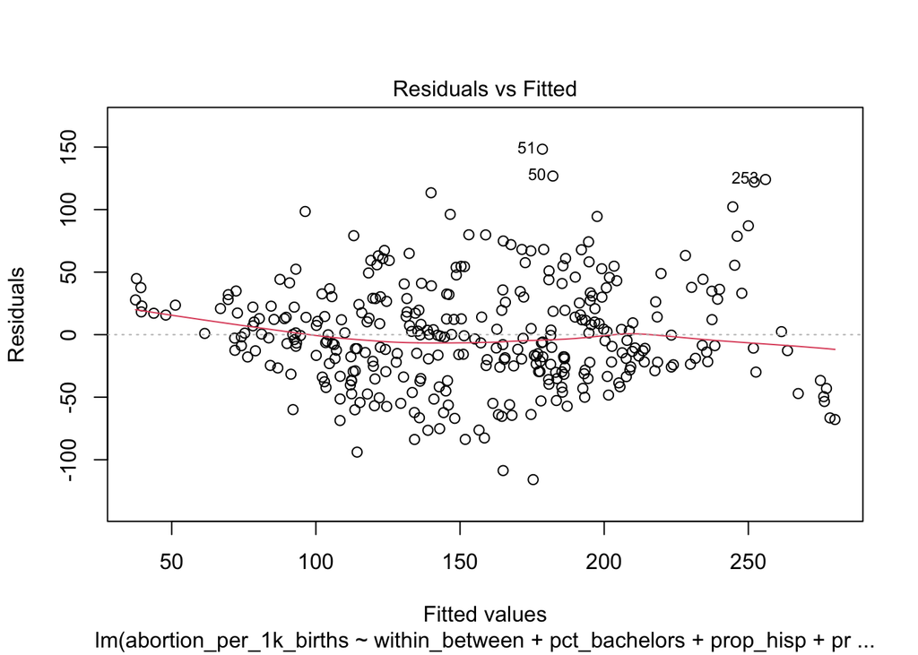

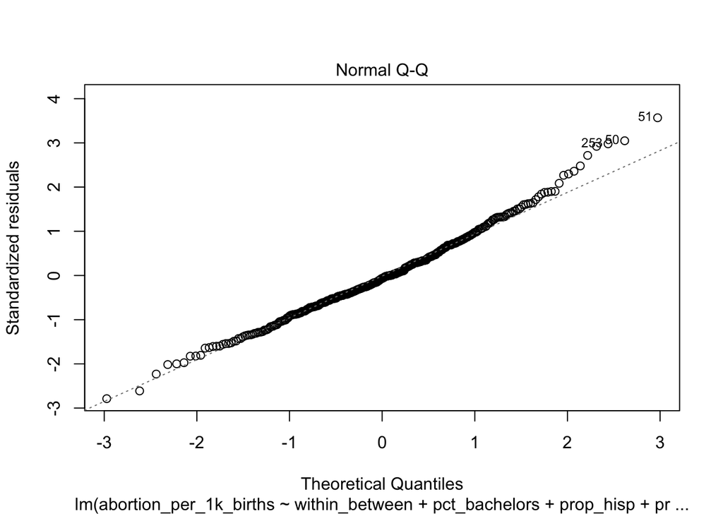

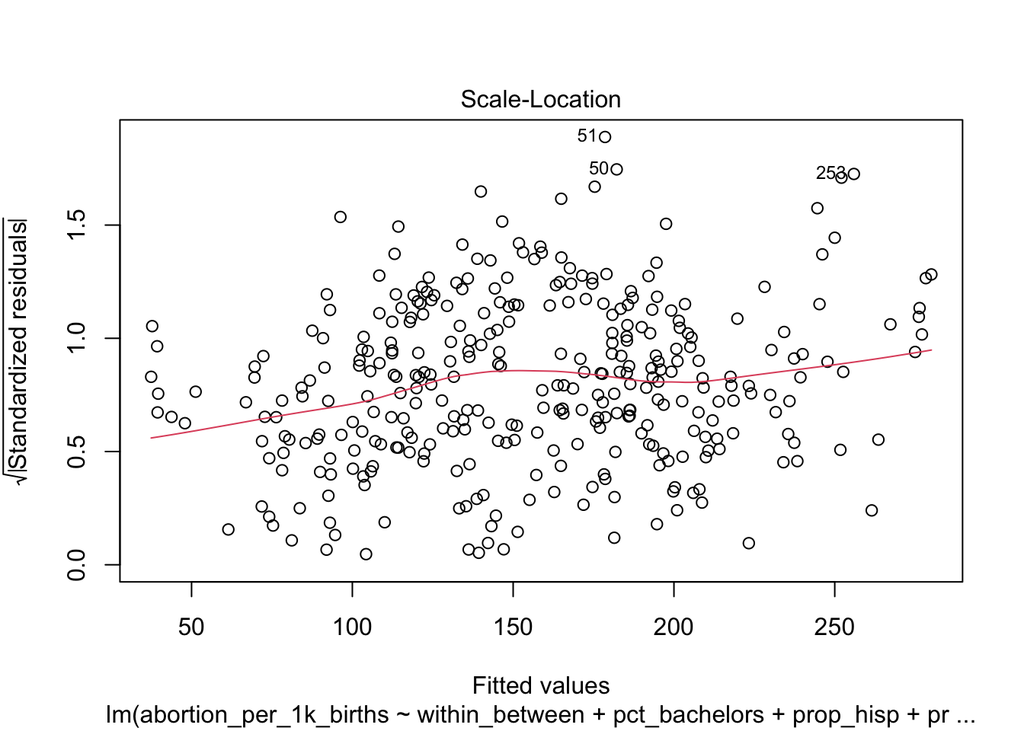

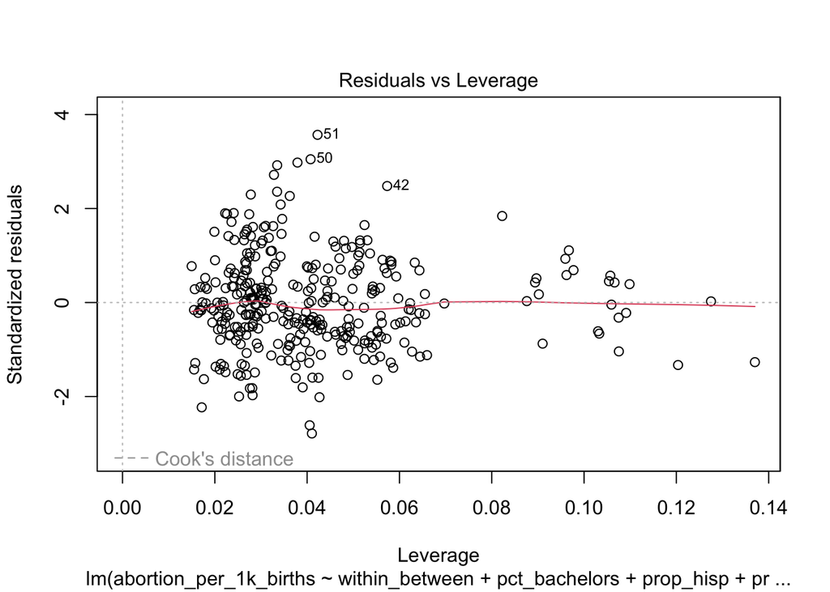

```r
plot(rate_lm)
```

We can also consider an OLS framework that accounts for heteroskedasticity in the errors by applying weights based on the number of births

```r
rate_wlm <- lm(abortion_per_1k_births ~ within_between + pct_bachelors +
                            prop_hisp + prop_nonwhite + hh_income + dem_2party,
               weights = births,
               data = usa@data)
lm.morantest(rate_wlm, listw = weights.contig.W)
```

```
##
##  Global Moran I for regression residuals
##
## data:
## model: lm(formula = abortion_per_1k_births ~ within_between +
## pct_bachelors + prop_hisp + prop_nonwhite + hh_income + dem_2party,
## data = usa@data, weights = births)
## weights: weights.contig.W
##
## Moran I statistic standard deviate = 5.6067, p-value = 1.031e-08
## alternative hypothesis: greater
## sample estimates:
## Observed Moran I      Expectation         Variance
##     0.0480904732    -0.0133290773     0.0001200049
```

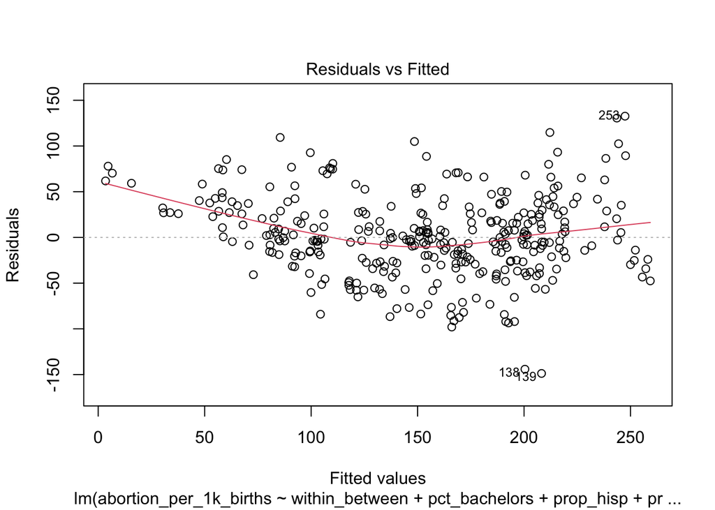

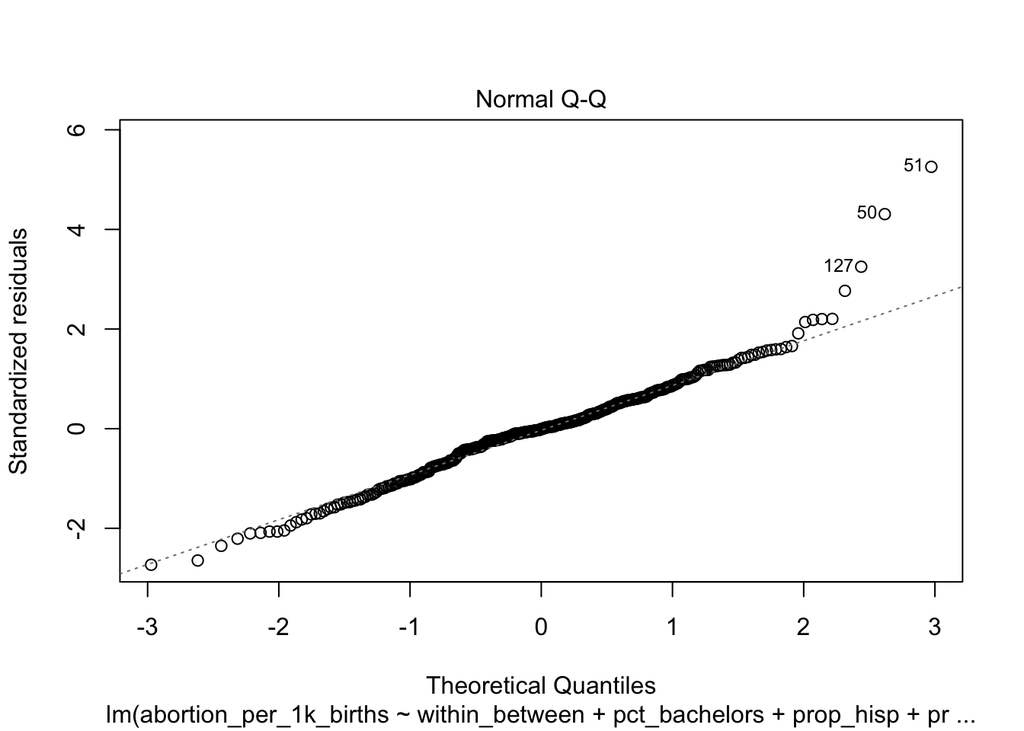

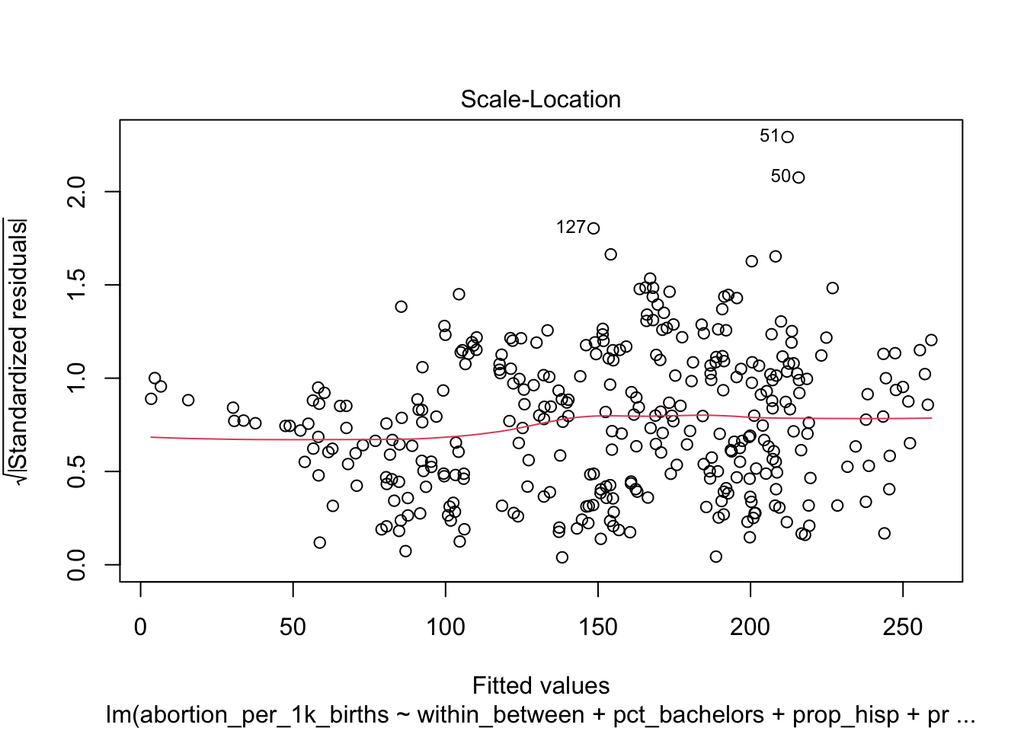

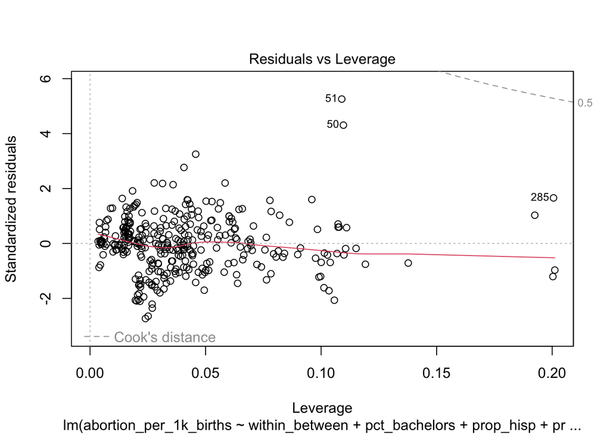

```r
plot(rate_wlm)
```

We still see evidence of spatial autocorrelation.

I will try to adjust for this with a standard CAR model